# Analysis of Fishes Dataset: Significant Differences in Weight, Length, Height, and Width Characteristics Across Clusters

## Cleaning Variable Names and Transforming Cluster to Factor

```r
df <- df %>%
  clean_names() %>%
  mutate_at(vars(cluster), factor) %>%
  glimpse()
```

```
## Rows: 159
## Columns: 8
## $ species <chr> "Bream", "Bream", "Bream", "Bream", "Bream", "Bream", "Bream",…
## $ weight  <dbl> 242, 290, 340, 363, 430, 450, 500, 390, 450, 500, 475, 500, 50…
## $ length1 <dbl> 23.2, 24.0, 23.9, 26.3, 26.5, 26.8, 26.8, 27.6, 27.6, 28.5, 28…
## $ length2 <dbl> 25.4, 26.3, 26.5, 29.0, 29.0, 29.7, 29.7, 30.0, 30.0, 30.7, 31…
## $ length3 <dbl> 30.0, 31.2, 31.1, 33.5, 34.0, 34.7, 34.5, 35.0, 35.1, 36.2, 36…
## $ height  <dbl> 11.5200, 12.4800, 12.3778, 12.7300, 12.4440, 13.6024, 14.1795,…
## $ width   <dbl> 4.0200, 4.3056, 4.6961, 4.4555, 5.1340, 4.9274, 5.2785, 4.6900…
## $ cluster <fct> 2, 2, 2, 1, 1, 1, 1, 1, 1, 1, 1, 1, 1, 1, 1, 1, 1, 1, 1, 1, 1,…
```

The variable name is processed through a cleaning procedure, and the `cluster` variable is considered as a factor.

## Counting Observations per Cluster

```r
df %>%
  group_by(cluster) %>%
  count() %>%
  flextable()
```

| cluster | n |
| --- | --- |
| 1 | 70 |
| 2 | 67 |
| 3 | 22 |

It is observed that there are 70 observations in Cluster 1, 67 observations in Cluster 2, and 22 observations in Cluster 3

## Between-Subjects Comparisons

### Normality test: `weight` and `cluster`

```r
df %>%
  group_by(cluster) %>%
  normality(weight) %>%
  flextable()
```

| variable | cluster | statistic | p_value | sample |
| --- | --- | --- | --- | --- |
| weight | 1 | 0.9205058 | 0.0002773090 | 70 |
| weight | 2 | 0.9468352 | 0.0063042066 | 67 |
| weight | 3 | 0.7869886 | 0.0003152546 | 22 |

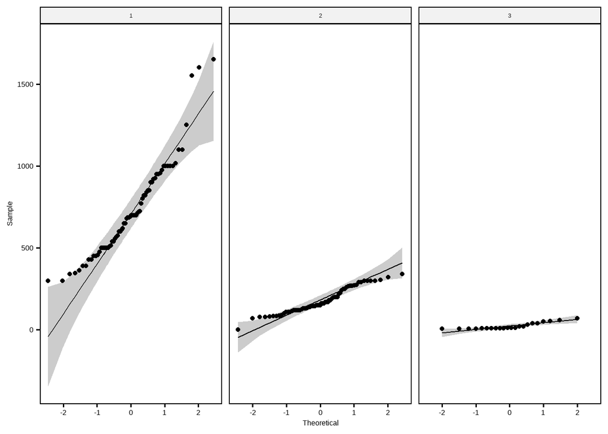

```r
ggqqplot(df, "weight", facet.by = "cluster")
```

The normality test results for the `weight` variable across different clusters indicate that the `weight` variable does not follow a normal distribution for all clusters. This result suggests that the assumption of normality has been violated.

### Levene’s Test for Homogeneity of Variance: `weight` and `cluster`

```r
leveneTest(weight ~ cluster, df)
```

```
## Levene's Test for Homogeneity of Variance (center = median)
##        Df F value    Pr(>F)
## group   2  32.809 1.278e-12 ***
##       156
## ---
## Signif. codes:  0 '***' 0.001 '**' 0.01 '*' 0.05 '.' 0.1 ' ' 1
```

The results from Levene’s Test for Homogeneity of Variance indicates a rejection of the null hypothesis that the variances are equal across groups or clusters. Therefore, it can be concluded that there is a significant difference in the variances of the `weight` variable across different clusters. This result suggests that the assumption of homogeneity of variances has been violated.

### Between-Subjects Comparisons: `weight` and `cluster`

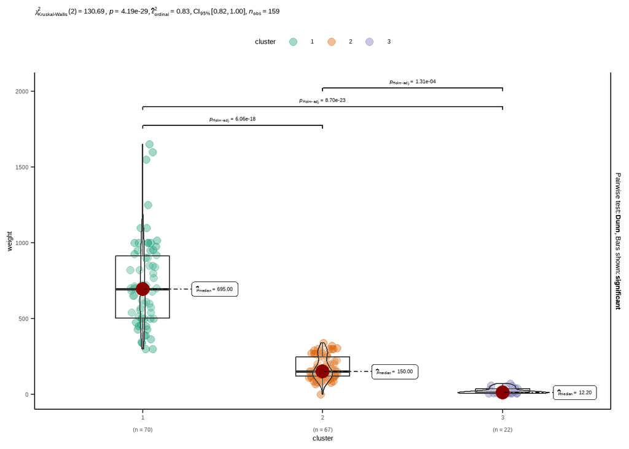

```r
ggbetweenstats(
  data = df,
  x    = cluster,
  y    = weight,
  type = "nonparametric",
  var.equal = FALSE
) +
  theme_classic() +
  theme(legend.position = "top")
```

Given the violation of the assumptions of normality, a non-parametric statistical test is employed with unequal variance. The Kruskal-Wallis test, a non-parametric method, is utilized in this case.

The result of the test indicates a rejection of the null hypothesis, as evidenced by a p-value of 4.19e-29 and a confidence interval of [0.82, 1.00]. This suggests that at least one group tends to yield larger values of weight than at least one of the other groups.

Further analysis using the Dunn test for pairwise comparisons reveals significant differences of weight between all pairs: clusters 1 and 2, 1 and 3, and 2 and 3. This is due to the adjusted p-value of Holm being less than 0.05 for all pairs, leading to the rejection of the null hypothesis of the Dunn test. This implies that at least one pair of groups has a significant difference.

It’s crucial to note that these differences are observed in rank-sums, not medians.

### Interpretation of Effect Size: `weight` and `cluster`

```r
interpret_epsilon_squared(0.83)
```

```
## [1] "large"
## (Rules: field2013)
```

The epsilon squared value of 0.83 is interpreted as ‘large’ according to Field’s (2013) guidelines, indicating a large effect size. This suggests that the variable `cluster` explains a large portion of the variance in `weight`.

### Diagnosis of Outlier: `weight` and `cluster`

```r
df %>%
  group_by(cluster) %>%
  diagnose_outlier(weight) %>%
  flextable()
```

| variables | cluster | data_cnt | outliers_cnt | outliers_ratio | outliers_mean | with_mean | without_mean |
| --- | --- | --- | --- | --- | --- | --- | --- |
| weight | 1 | 70 | 2 | 2.857143 | 1,625 | 729.14286 | 702.79412 |
| weight | 2 | 67 | 0 | 0.000000 |  | 175.87761 | 175.87761 |
| weight | 3 | 22 | 0 | 0.000000 |  | 23.22273 | 23.22273 |

Outlier diagnostics indicate the presence of potentially influential outliers in the dataset. As a result, the application of robust statistical testing methods is recommended.

### Between-Subjects Comparisons via Robust Test: `weight` and `cluster`

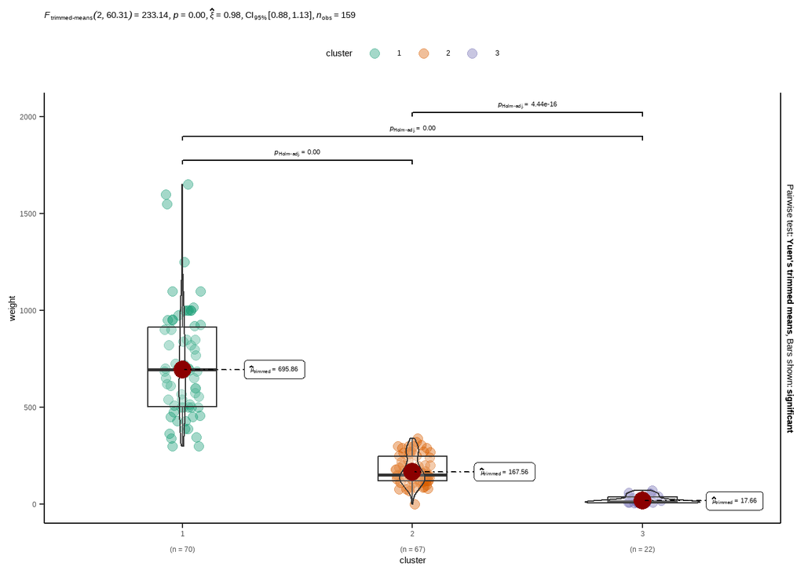

```r
ggbetweenstats(
  data = df,
  x    = cluster,
  y    = weight,
  type = "robust",
  var.equal = FALSE
) +
  theme_classic() +
  theme(legend.position = "top")
```

Further analysis using the Yuen’s trimmed means test for pairwise comparisons reveals significant differences of weight between all pairs: clusters 1 and 2, 1 and 3, and 2 and 3. This is due to the adjusted p-value of Holm being less than 0.05 for all pairs, leading to the rejection of the null hypothesis of the Yuen’s trimmed means test. This implies that the weights of the individuals in these clusters are significantly different from each other.

### Normality test: `length1` (vertical length) and `cluster`

```r
df %>%
  group_by(cluster) %>%
  normality(length1) %>%
  flextable()
```

| variable | cluster | statistic | p_value | sample |
| --- | --- | --- | --- | --- |
| length1 | 1 | 0.8704818 | 0.000003174804 | 70 |
| length1 | 2 | 0.9605173 | 0.032211707082 | 67 |
| length1 | 3 | 0.9872169 | 0.988879627193 | 22 |

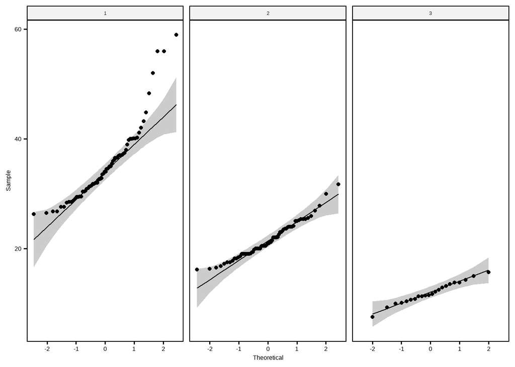

```r
ggqqplot(df, "length1", facet.by = "cluster")
```

### Levene’s Test for Homogeneity of Variance: `length1` (vertical length) and `cluster`

```r
leveneTest(length1 ~ cluster, df)
```

```
## Levene's Test for Homogeneity of Variance (center = median)
##        Df F value    Pr(>F)
## group   2  11.078 3.172e-05 ***
##       156
## ---
## Signif. codes:  0 '***' 0.001 '**' 0.01 '*' 0.05 '.' 0.1 ' ' 1
```

The results from Levene’s Test for Homogeneity of Variance indicates a rejection of the null hypothesis that the variances are equal across groups or clusters. Therefore, it can be concluded that there is a significant difference in the variances of the `length1` variable across different clusters. This result suggests that the assumption of homogeneity of variances has been violated.

### Between-Subjects Comparisons: `length1` (vertical length) and `cluster`

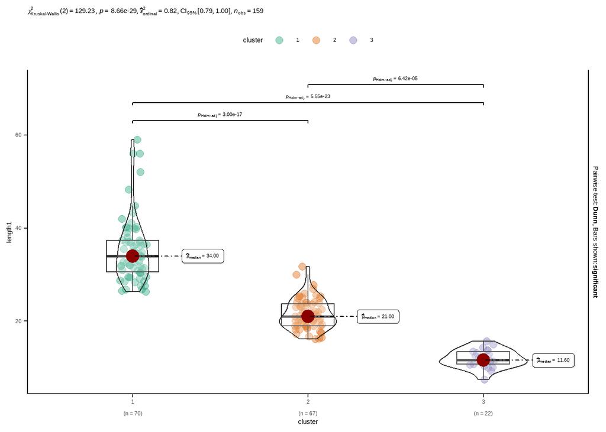

```r
ggbetweenstats(
  data = df,
  x    = cluster,
  y    = length1,
  type = "nonparametric",
  var.equal = FALSE
) +
  theme_classic() +
  theme(legend.position = "top")
```

Given the violation of the assumptions of normality, a non-parametric statistical test is employed with unequal variance. The Kruskal-Wallis test, a non-parametric method, is utilized in this case.

The result of the test indicates a rejection of the null hypothesis, as evidenced by a p-value of 8.66e-29 and a confidence interval of [0.79, 1.00]. This suggests that at least one group tends to yield larger values of vertical length than at least one of the other groups.

Further analysis using the Dunn test for pairwise comparisons reveals significant differences of vertical length between all pairs: clusters 1 and 2, 1 and 3, and 2 and 3. This is due to the adjusted p-value of Holm being less than 0.05 for all pairs, leading to the rejection of the null hypothesis of the Dunn test. This implies that at least one pair of groups has a significant difference.

It’s crucial to note that these differences are observed in rank-sums, not medians.

### Interpretation of Effect Size: `length1` (vertical length) and `cluster`

```r
interpret_epsilon_squared(0.82)
```

```
## [1] "large"
## (Rules: field2013)
```

The epsilon squared value of 0.82 is interpreted as ‘large’ according to Field’s (2013) guidelines, indicating a large effect size. This suggests that the variable `cluster` explains a large portion of the variance in `length1` (vertical length).

### Diagnosis of Outlier: `length1` (vertical length) and `cluster`

```r
df %>%
  group_by(cluster) %>%
  diagnose_outlier(length1) %>%
  flextable()
```

| variables | cluster | data_cnt | outliers_cnt | outliers_ratio | outliers_mean | with_mean | without_mean |
| --- | --- | --- | --- | --- | --- | --- | --- |
| length1 | 1 | 70 | 5 | 7.142857 | 54.26 | 35.27000 | 33.80923 |
| length1 | 2 | 67 | 1 | 1.492537 | 31.70 | 21.51642 | 21.36212 |
| length1 | 3 | 22 | 0 | 0.000000 |  | 11.94545 | 11.94545 |

### Normality test `length2` (diagonal length) and `cluster`

```r
df %>%
  group_by(cluster) %>%
  normality(length2) %>%
  flextable()
```

| variable | cluster | statistic | p_value | sample |
| --- | --- | --- | --- | --- |
| length2 | 1 | 0.8631431 | 0.000001791128 | 70 |
| length2 | 2 | 0.9614298 | 0.036047616753 | 67 |
| length2 | 3 | 0.9817431 | 0.941034790860 | 22 |

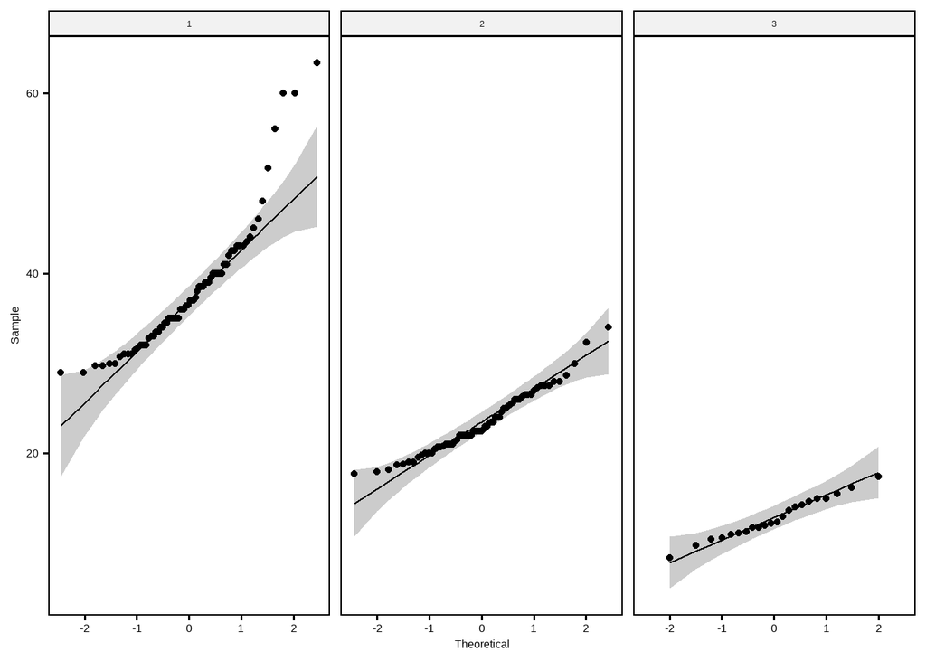

```r
ggqqplot(df, "length2", facet.by = "cluster")
```

### Levene’s Test for Homogeneity of Variance: `length2` (diagonal length) and `cluster`

```r
leveneTest(length2 ~ cluster, df)
```

```
## Levene's Test for Homogeneity of Variance (center = median)
##        Df F value   Pr(>F)
## group   2  9.7218 0.000105 ***
##       156
## ---
## Signif. codes:  0 '***' 0.001 '**' 0.01 '*' 0.05 '.' 0.1 ' ' 1
```

The results from Levene’s Test for Homogeneity of Variance indicates a rejection of the null hypothesis that the variances are equal across groups or clusters. Therefore, it can be concluded that there is a significant difference in the variances of the `length2` variable across different clusters. This result suggests that the assumption of homogeneity of variances has been violated.

### Between-Subjects Comparisons: `length2` (diagonal length) and `cluster`

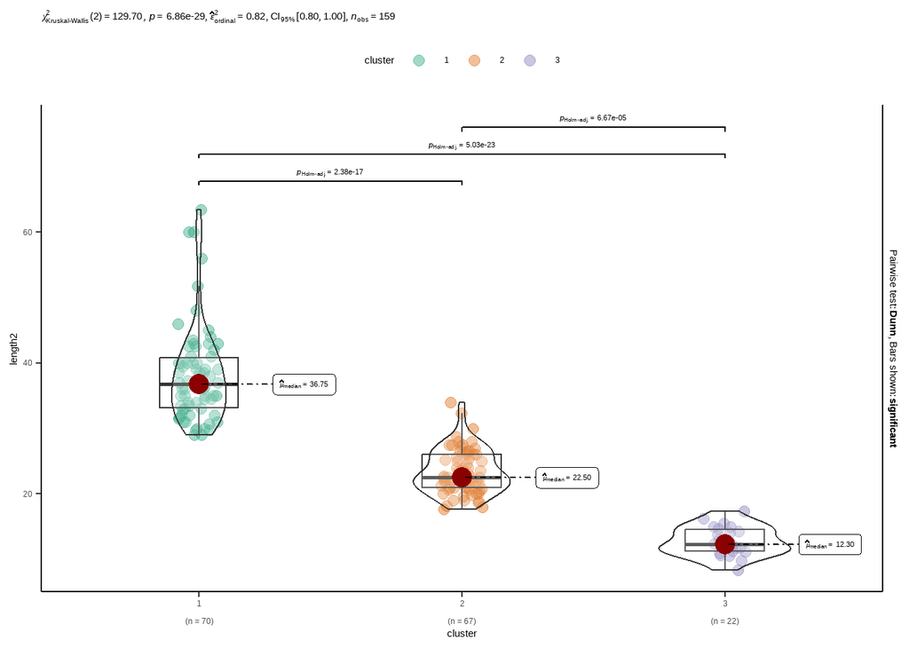

```r
ggbetweenstats(
  data = df,
  x    = cluster,
  y    = length2,
  type = "nonparametric",
  var.equal = FALSE
) +
  theme_classic() +
  theme(legend.position = "top")
```

Given the violation of the assumptions of normality, a non-parametric statistical test is employed with unequal variance. The Kruskal-Wallis test, a non-parametric method, is utilized in this case.

The result of the test indicates a rejection of the null hypothesis, as evidenced by a p-value of 6.86e-29 and a confidence interval of [0.80, 1.00]. This suggests that at least one group tends to yield larger values of diagonal length than at least one of the other groups.

Further analysis using the Dunn test for pairwise comparisons reveals significant differences of diagonal length between all pairs: clusters 1 and 2, 1 and 3, and 2 and 3. This is due to the adjusted p-value of Holm being less than 0.05 for all pairs, leading to the rejection of the null hypothesis of the Dunn test. This implies that at least one pair of groups has a significant difference.

It’s crucial to note that these differences are observed in rank-sums, not medians.

### Interpretation of Effect Size: `length2` (diagonal length) and `cluster`

```r
interpret_epsilon_squared(0.82)
```

```
## [1] "large"
## (Rules: field2013)
```

The epsilon squared value of 0.82 is interpreted as ‘large’ according to Field’s (2013) guidelines, indicating a large effect size. This suggests that the variable `cluster` explains a large portion of the variance in `length2` (diagonal length).

### Diagnosis of Outlier: `length2` (diagonal length) and `cluster`

```r
df %>%
  group_by(cluster) %>%
  diagnose_outlier(length2) %>%
  flextable()
```

| variables | cluster | data_cnt | outliers_cnt | outliers_ratio | outliers_mean | with_mean | without_mean |
| --- | --- | --- | --- | --- | --- | --- | --- |
| length2 | 1 | 70 | 4 | 5.714286 | 59.85 | 38.11286 | 36.79545 |
| length2 | 2 | 67 | 1 | 1.492537 | 34.00 | 23.40746 | 23.24697 |
| length2 | 3 | 22 | 0 | 0.000000 |  | 12.81364 | 12.81364 |

### Normality test `length3` (cross length) and `cluster`

```r
df %>%
  group_by(cluster) %>%
  normality(length3) %>%
  flextable()
```

| variable | cluster | statistic | p_value | sample |
| --- | --- | --- | --- | --- |
| length3 | 1 | 0.8268957 | 0.0000001336178 | 70 |
| length3 | 2 | 0.9613253 | 0.0355857041204 | 67 |
| length3 | 3 | 0.9753849 | 0.8308710085545 | 22 |

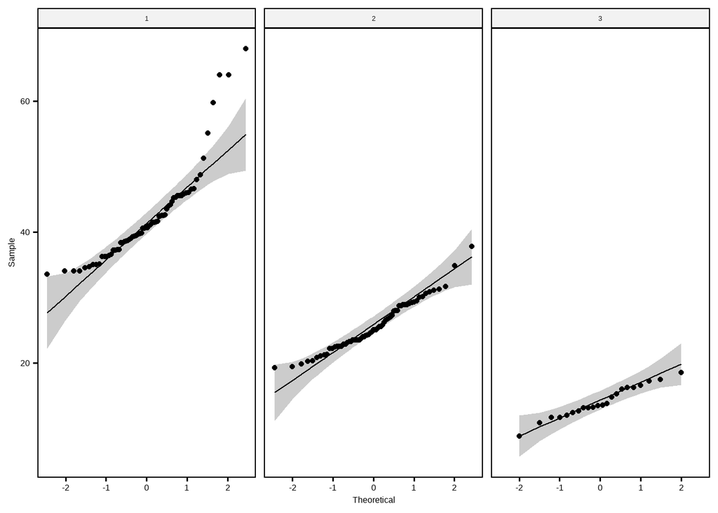

```r
ggqqplot(df, "length3", facet.by = "cluster")
```

### Levene’s Test for Homogeneity of Variance: `length3` (cross length) and `cluster`

```r
leveneTest(length3 ~ cluster, df)
```

```
## Levene's Test for Homogeneity of Variance (center = median)
##        Df F value   Pr(>F)
## group   2  5.2843 0.006018 **
##       156
## ---
## Signif. codes:  0 '***' 0.001 '**' 0.01 '*' 0.05 '.' 0.1 ' ' 1
```

The results from Levene’s Test for Homogeneity of Variance indicates a rejection of the null hypothesis that the variances are equal across groups or clusters. Therefore, it can be concluded that there is a significant difference in the variances of the `length3` variable across different clusters. This result suggests that the assumption of homogeneity of variances has been violated.

### Between-Subjects Comparisons: `length3` (cross length) and `cluster`

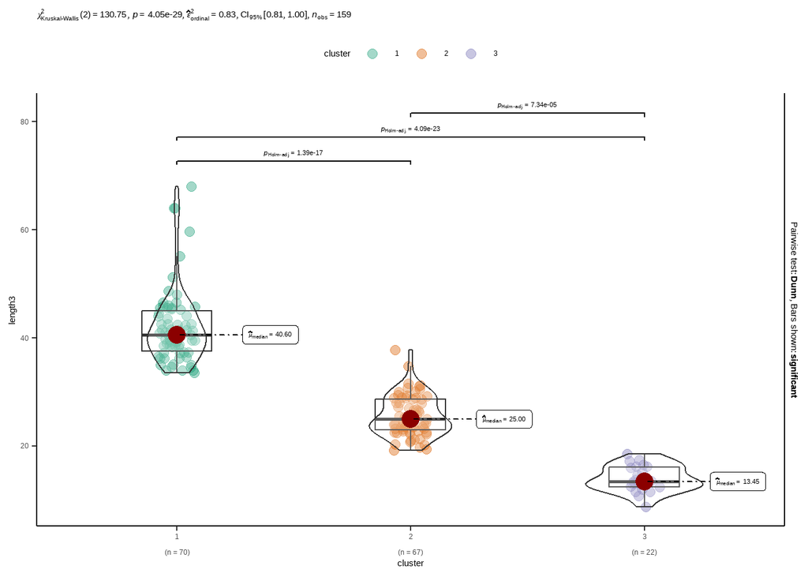

```r
ggbetweenstats(
  data = df,
  x    = cluster,
  y    = length3,
  type = "nonparametric",
  var.equal = FALSE
) +
  theme_classic() +
  theme(legend.position = "top")
```

Given the violation of the assumptions of normality, a non-parametric statistical test is employed with unequal variance. The Kruskal-Wallis test, a non-parametric method, is utilized in this case.

The result of the test indicates a rejection of the null hypothesis, as evidenced by a p-value of 4.05e-29 and a confidence interval of [0.81, 1.00]. This suggests that at least one group tends to yield larger values of cross length than at least one of the other groups.

Further analysis using the Dunn test for pairwise comparisons reveals significant differences of cross length between all pairs: clusters 1 and 2, 1 and 3, and 2 and 3. This is due to the adjusted p-value of Holm being less than 0.05 for all pairs, leading to the rejection of the null hypothesis of the Dunn test. This implies that at least one pair of groups has a significant difference.

It’s crucial to note that these differences are observed in rank-sums, not medians.

### Interpretation of Effect Size: `length3` (cross length) and `cluster`

```r
interpret_epsilon_squared(0.83)
```

```
## [1] "large"
## (Rules: field2013)
```

The epsilon squared value of 0.83 is interpreted as ‘large’ according to Field’s (2013) guidelines, indicating a large effect size. This suggests that the variable `cluster` explains a large portion of the variance in `length3` (cross length).

### Diagnosis of Outlier: `length3` (cross length) and `cluster`

```r
df %>%
  group_by(cluster) %>%
  diagnose_outlier(length3) %>%
  flextable()
```

| variables | cluster | data_cnt | outliers_cnt | outliers_ratio | outliers_mean | with_mean | without_mean |
| --- | --- | --- | --- | --- | --- | --- | --- |
| length3 | 1 | 70 | 4 | 5.714286 | 63.925 | 42.04714 | 40.72121 |
| length3 | 2 | 67 | 1 | 1.492537 | 37.800 | 25.58209 | 25.39697 |
| length3 | 3 | 22 | 0 | 0.000000 |  | 13.99091 | 13.99091 |

### Normality test `height` and `cluster`

```r
df %>%
  group_by(cluster) %>%
  normality(height) %>%
  flextable()
```

| variable | cluster | statistic | p_value | sample |
| --- | --- | --- | --- | --- |
| height | 1 | 0.9784901 | 0.270835373062 | 70 |
| height | 2 | 0.8694779 | 0.000004437802 | 67 |
| height | 3 | 0.7824451 | 0.000269151564 | 22 |

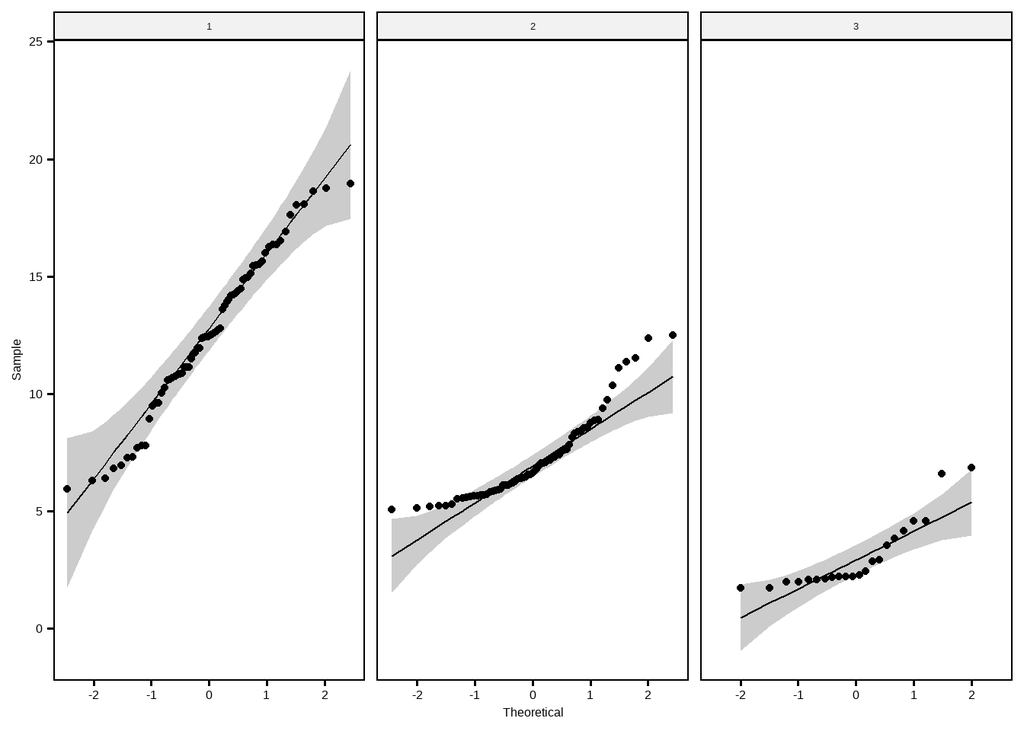

```r
ggqqplot(df, "height", facet.by = "cluster")
```

### Levene’s Test for Homogeneity of Variance: `height` and `cluster`

```r
leveneTest(height ~ cluster, df)
```

```
## Levene's Test for Homogeneity of Variance (center = median)
##        Df F value    Pr(>F)
## group   2  15.707 6.098e-07 ***
##       156
## ---
## Signif. codes:  0 '***' 0.001 '**' 0.01 '*' 0.05 '.' 0.1 ' ' 1
```

The results from Levene’s Test for Homogeneity of Variance indicates a rejection of the null hypothesis that the variances are equal across groups or clusters. Therefore, it can be concluded that there is a significant difference in the variances of the `height` variable across different clusters. This result suggests that the assumption of homogeneity of variances has been violated.

### Between-Subjects Comparisons: `height` and `cluster`

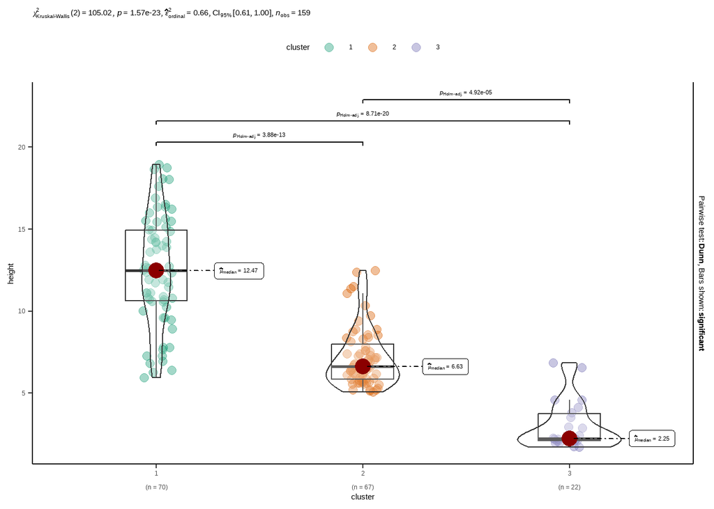

```r
ggbetweenstats(
  data = df,
  x    = cluster,
  y    = height,
  type = "nonparametric",
  var.equal = FALSE
) +
  theme_classic() +
  theme(legend.position = "top")
```

Given the violation of the assumptions of normality, a non-parametric statistical test is employed with unequal variance. The Kruskal-Wallis test, a non-parametric method, is utilized in this case.

Further analysis using the Dunn test for pairwise comparisons reveals significant differences of height between all pairs: clusters 1 and 2, 1 and 3, and 2 and 3. This is due to the adjusted p-value of Holm being less than 0.05 for all pairs, leading to the rejection of the null hypothesis of the Dunn test. This implies that at least one pair of groups has a significant difference.

It’s crucial to note that these differences are observed in rank-sums, not medians.

### Interpretation of Effect Size: `height` and `cluster`

```r
interpret_epsilon_squared(0.66)
```

```
## [1] "large"
## (Rules: field2013)
```

The epsilon squared value of 0.66 is interpreted as ‘large’ according to Field’s (2013) guidelines, indicating a large effect size. This suggests that the variable `cluster` explains a large portion of the variance in `height`

### Diagnosis of Outlier: `height` and `cluster`

```r
df %>%
  group_by(cluster) %>%
  diagnose_outlier(height) %>%
  flextable()
```

| variables | cluster | data_cnt | outliers_cnt | outliers_ratio | outliers_mean | with_mean | without_mean |
| --- | --- | --- | --- | --- | --- | --- | --- |
| height | 1 | 70 | 0 | 0.000000 |  | 12.544657 | 12.544657 |
| height | 2 | 67 | 4 | 5.970149 | 11.93645 | 7.180813 | 6.878868 |
| height | 3 | 22 | 2 | 9.090909 | 6.71235 | 3.052159 | 2.686140 |

Outlier diagnostics indicate the presence of potentially influential outliers in the dataset. As a result, the application of robust statistical testing methods is recommended.

### Between-Subjects Comparisons via Robust Test: `height` and `cluster`

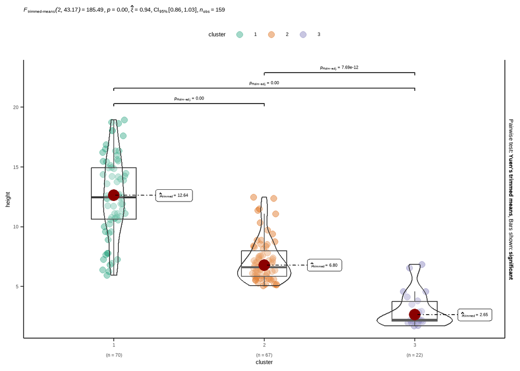

```r
ggbetweenstats(
  data = df,
  x    = cluster,
  y    = height,
  type = "robust",
  var.equal = FALSE
) +
  theme_classic() +
  theme(legend.position = "top")
```

Further analysis using the Yuen’s trimmed means test for pairwise comparisons reveals significant differences of height between all pairs: clusters 1 and 2, 1 and 3, and 2 and 3. This is due to the adjusted p-value of Holm being less than 0.05 for all pairs, leading to the rejection of the null hypothesis of the Yuen’s trimmed means test. This implies that the height of the individuals in these clusters are significantly different from each other.

### Normality test `width` and `cluster`

```r
df %>%
  group_by(cluster) %>%
  normality(width) %>%
  flextable()
```

| variable | cluster | statistic | p_value | sample |
| --- | --- | --- | --- | --- |
| width | 1 | 0.9764546 | 0.20985973 | 70 |
| width | 2 | 0.9810700 | 0.39950425 | 67 |
| width | 3 | 0.8536771 | 0.00394575 | 22 |

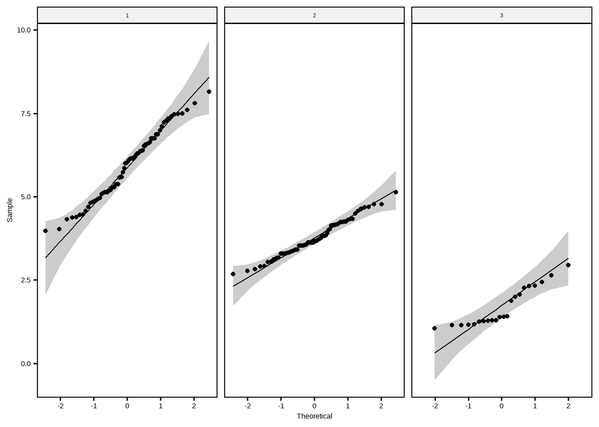

```r
ggqqplot(df, "width", facet.by = "cluster")
```

### Levene’s Test for Homogeneity of Variance: `width` and `cluster`

```r
leveneTest(width ~ cluster, df)
```

```
## Levene's Test for Homogeneity of Variance (center = median)
##        Df F value    Pr(>F)
## group   2  16.475 3.225e-07 ***
##       156
## ---
## Signif. codes:  0 '***' 0.001 '**' 0.01 '*' 0.05 '.' 0.1 ' ' 1
```

The results from Levene’s Test for Homogeneity of Variance indicates a rejection of the null hypothesis that the variances are equal across groups or clusters. Therefore, it can be concluded that there is a significant difference in the variances of the `width` variable across different clusters. This result suggests that the assumption of homogeneity of variances has been violated.

### Between-Subjects Comparisons: `width` and `cluster`

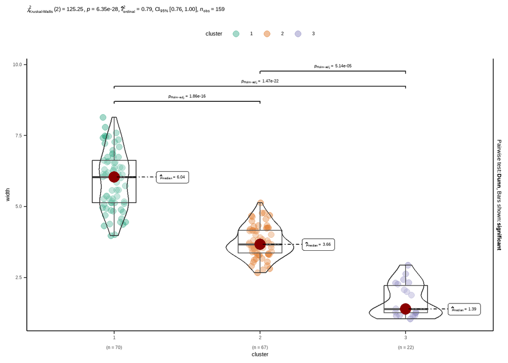

```r
ggbetweenstats(
  data = df,
  x    = cluster,
  y    = width,
  type = "nonparametric",
  var.equal = FALSE
) +
  theme_classic() +
  theme(legend.position = "top")
```

Given the violation of the assumptions of normality, a non-parametric statistical test is employed with unequal variance. The Kruskal-Wallis test, a non-parametric method, is utilized in this case.

The result of the test indicates a rejection of the null hypothesis, as evidenced by a p-value of 6.35e-28 and a confidence interval of [0.76, 1.00]. This suggests that at least one group tends to yield larger values of width than at least one of the other groups.

Further analysis using the Dunn test for pairwise comparisons reveals significant differences of width between all pairs: clusters 1 and 2, 1 and 3, and 2 and 3. This is due to the adjusted p-value of Holm being less than 0.05 for all pairs, leading to the rejection of the null hypothesis of the Dunn test. This implies that at least one pair of groups has a significant difference.

It’s crucial to note that these differences are observed in rank-sums, not medians.

### Interpretation of Effect Size: `width` and `cluster`

```r
interpret_epsilon_squared(0.79)
```

```
## [1] "large"
## (Rules: field2013)
```

The epsilon squared value of 0.79 is interpreted as ‘large’ according to Field’s (2013) guidelines, indicating a large effect size. This suggests that the variable `cluster` explains a large portion of the variance in `width`

### Diagnosis of Outlier: `width` and `cluster`

```r
df %>%
  group_by(cluster) %>%
  diagnose_outlier(width) %>%
  flextable()
```

| variables | cluster | data_cnt | outliers_cnt | outliers_ratio | outliers_mean | with_mean | without_mean |
| --- | --- | --- | --- | --- | --- | --- | --- |
| width | 1 | 70 | 0 | 0 |  | 5.912914 | 5.912914 |
| width | 2 | 67 | 0 | 0 |  | 3.752148 | 3.752148 |
| width | 3 | 22 | 0 | 0 |  | 1.685559 | 1.685559 |

Outlier diagnostics indicate that there is no presence of potentially influential outliers in the dataset. As a result, the application of robust statistical testing methods is not necessary.

# Conclusion

The presence of potentially influential outliers in the dataset for `weight` and `height` suggests the need for robust statistical testing methods for these variables. The Heteroscedastic one-way ANOVA for trimmed means and Yuen’s trimmed means test are used and the result also indicates significant differences in group means.